# Data Quality Report

2022 Mpox Multi-Jurisdictional Case-Control VE Public Health Evaluation

Report by Case-Control Unit | VE Team | VTF | 2022 Multinational Monkeypox Response

16 January 2023

## **Report objective**

Examine data quality, clean data, and create analysis variables.

```r
# Data in: Pulled data directly from REDCap using API token
# Initial program date: 2022-12-15
# Last modified date: 2022-12-19

# Load packages --------------------------------
  pacman::p_load(here,        # file paths relative to R project root folder
                 rio,         # import/export
                 readxl,      # read excel files
                 tidyverse,    # data management and visualization
                 purrr,        # iteration
                 janitor,      # data management: cleaning and exploring data
                 lubridate,    # working with dates/epiweeks
                 naniar,       # Working with data structures, summaries, and visualizations for Missing Data
                 arsenal,      # provides unctions for large-scale statistical summaries
                 ggsci,        # scientific journal and sci-fi themed color palettes for 'ggplot2'
                 cowplot,      # streamlined plot theme and plot annotations for 'ggplot2'
                 knitr,        # Provides a general-purpose tool for dynamic report generation in R
                 kableExtra,   # simplifies the way to manipulate the HTML or 'LaTeX' codes generated by 'kable()
                 DT,           # provides an R interface to the JavaScript library DataTables
                 gtsummary,    # publication-ready analytical and summary tables
                 stargazer,    # provides a way to create publication quality tables
                 plotly        # creates interactive web-based graphs


  )

# Global option number format
  options(scipen = 9999)

  theme_gtsummary_journal(journal = "jama")
  theme_gtsummary_compact()
# Helper (custom functions) ------------------------------------------------------------
#This function replicates the SAS proc freq function with the '/ list missing statement'.
#Source: https://github.com/asnr/sas-to-r
pfreq = function(...) {
  dplyr::group_by(...) %>%
    dplyr::summarize(n = n()) %>%
    dplyr::mutate(pct= round(100 * n/sum(n), 1))
  #mutate(Percent=paste0(round(100 * n/sum(n), 1), "%"))
}

# This function helps create consistent values for Yes/No variables.
# by reassigning '2' values a zero.
give_two_a_zero <- function(x){
  x[x == 2 ] <- 0
  x
}


# Source data and define environment variables ---------------------------------------------------------------------

  source("00_REDCap-API-linkage.R", local =knit_global())


  # This the date of the earliest symptom per the study protocol,
  # but there is flexibility around this date to account for recall bias.
  eligibility_date <- ymd("2022-08-19")

  eligibility_date_v2 <- "19 Aug 2022"

  # This date represent the most recent data transfer from jurisdictions
  redcap_trans_date <- ymd("2023-01-06")

  redcap_trans_date_v2 <- "06 Jan 2023"


# Tidy data ----------------------------------------------------------------------
mpoxve <- raw %>%
    # Restrict to eligible participants (i.e., those that passed the eligibility screening)
    filter(inelig_stop ==  1) %>%
    # Restrict to those who have data for relevent eligibility screening questions
    filter(!if_all(c(elig_age, elig_sexuality, elig_gender,
                     elig_gender_msm, elig_sexual_partners,
                     elig_healthcare), is.na)) %>%
    mutate(#! Variable name key:
               #!  *_cat: indicates a categorical these are flags (0/1)
               #!  *_f: these are flags (0/1)
               #!  *_na: these are also flags but specifically related to missingness (NA = missing in R)
               #!  *_int: these refer to some calculate interval
               #!  pd: an abbreviation for period
          # Format all yes/no variables with 1(Yes)/2(No) values as 1(Yes)/0(No).
           across(contains(c("elig_age", "elig_gender_msm", "elig_sexual_partners",
                             "elig_healthcare", "first_dose_yesno", "second_dose_yesno",
                             "symptoms_yesno", "provider_dx", "clinic_yesno", "hospitalized",
                             "dose1_yesno", "dose2_yesno"), ignore.case = TRUE), give_two_a_zero),


           # Format all date variables as YYYY-MM-DD
           across(contains("_date", ignore.case = TRUE), ymd),
           # Check the presence of a jurisdiction ID
           juris_detect = case_when(str_detect(pid, "CA_|CO_| CT_|DC_|GA_|LAC_|MD_|MN_|NYC_|NYS_|OR_|TN_") ~ 1,
                           TRUE ~ as.numeric(0)),

           # Rename REDCap Data Access Group variable and capitalize the letters
           jid = fct_relevel(as_factor(toupper(redcap_data_access_group)),
                             "CA", "LAC", "CO", "CT", "GA", "MD", "MN",
                             "NYS", "NYC", "OR", "TN", "DC"),

           # Case Ascertainment: Symptomatic cases identified by state or local health departments who meet either
           #                     the confirmed or probable case definition will be eligible for inclusion.
           #                     #! If a participant self-reports as a cases and the rest of their data
           #                        are consistent with being a case then we should follow-up with the
           #                        with he jurisdiction to confirm. We will likely include this participant as a case.


           # Create indicator vars to help flag records missing minimum set of data elements need for VE  variables

           provider_dx_na = case_when(is.na(provider_dx) ~ 1,
                                     TRUE ~ as.numeric(0)),

           clinic_yesno_na = case_when((provider_dx == 0 | is.na(provider_dx)) & is.na(clinic_yesno) ~ 1,
                                       TRUE ~ as.numeric(0)),

           clinic_date_na = case_when(clinic_yesno == 1 & is.na(clinic_date) ~ 1,
                                      TRUE ~ as.numeric(0)),

           symptoms_yesno_na = case_when(is.na(symptoms_yesno) ~ 1,
                                         TRUE ~ as.numeric(0)),

           symptoms_date_na = case_when(symptoms_yesno == 1 & is.na(symptoms_date) ~ 1,
                                        TRUE ~ as.numeric(0)),
```

```r
           first_dose_yesno_na = case_when(is.na(first_dose_yesno) ~ 1,
                                           TRUE ~ as.numeric(0)),

           first_dose_date_na = case_when(first_dose_yesno == 1 & is.na(first_dose_date) ~ 1,
                                          TRUE ~ as.numeric(0)),

           second_dose_yesno_na = case_when(first_dose_yesno == 1 & is.na(second_dose_yesno) ~ 1,
                                            TRUE ~ as.numeric(0)),

           second_dose_date_na = case_when(second_dose_yesno == 1 & is.na(second_dose_date) ~ 1,
                                           TRUE ~ as.numeric(0)),

           # Flag records missing any minimum set of data element needed for VE estimate
           minset_vars_self = ifelse(if_any(contains("_na"), ~ . == 1), 0, 1),

           # Create indicator vars to help flag records missing jurisdiction completed vax info

           case_yesno_na = case_when(is.na(case_yesno) ~ 1,
                                     TRUE ~ as.numeric(0)),

           test_result_date_na = case_when(case_yesno %in% c(1:2) & is.na(test_result_date) ~ 1,
                                           TRUE ~ as.numeric(0)),

           control_visit_date_na = case_when(case_yesno == 3 & is.na(control_visit_date) ~ 1,
                                              TRUE ~ as.numeric(0)),

           dose1_yesno_na = case_when(is.na(dose1_yesno) ~ 1,
                                      TRUE ~ as.numeric(0)),

           dose1_date_na = case_when(dose1_yesno == 1 & is.na(dose1_date) ~ 1,
                                     TRUE ~ as.numeric(0)),

           dose2_yesno_na = case_when(dose1_yesno == 1 & is.na(dose2_yesno) ~ 1,
                                      TRUE ~ as.numeric(0)),

           dose2_date_na = case_when(dose2_yesno == 1 & is.na(dose2_date) ~ 1,
                                     TRUE ~ as.numeric(0)),


           # Flag records missing any minimum set of data element needed for VE estimate
           minset_vars_site = ifelse(if_any(c("case_yesno_na", "test_result_date_na", "control_visit_date_na",
                                              "dose1_yesno_na", "dose1_date_na",
                                              "dose2_yesno_na", "dose2_date_na",
                                              "symptoms_yesno_na", "symptoms_date_na"), ~ . == 1), 0, 1),


          # Although not part of data quality check report, flag mpox symptoms date within 2022-08-19 and system date.
           study_pd_int = interval(eligibility_date, redcap_trans_date),

           study_pd_int_site_f = case_when((test_result_date %within% study_pd_int) |
                                                   (control_visit_date %within% study_pd_int) ~ 1,
                                                 ((test_result_date < eligibility_date |
                                                   control_visit_date < eligibility_date) |
                                                   (test_result_date > redcap_trans_date |
                                                      control_visit_date > redcap_trans_date)) ~ 0,
                                            TRUE ~ as.numeric(NA)),

           study_pd_int_self_f = case_when((symptoms_date %within% study_pd_int) |
                                                   (clinic_date %within% study_pd_int) ~ 1,
                                                 ((symptoms_date < eligibility_date |
                                                   clinic_date < eligibility_date) |
                                                   (symptoms_date > redcap_trans_date |
                                                      clinic_date > redcap_trans_date)) ~ 0,
                                            TRUE ~ as.numeric(NA)),
            # Case Status – site vs Self Report - Compare case status from health department to self-reported mpox diagnosis
           caco_stat_match_f = fct_relevel(as_factor(case_when(case_yesno %in% c(1,2) & provider_dx == 0 ~ "Discrepancy: site case",
                                                               case_yesno == 3 & (provider_dx == 1 | symptoms_yesno == 1)  ~ "Discrepancy: self case",

                                                               case_yesno %in% c(1,2) & provider_dx == 1 ~ "Case: site & self",
                                                               is.na(case_yesno)  & provider_dx == 1 ~ "Case: self but site missing",
                                                               case_yesno == 3 & provider_dx == 0 ~ "Control: site & self",
                                                               is.na(case_yesno)  & provider_dx == 0 ~ "Control: self but site missing",
                                                               TRUE ~ as.character(NA))),
                                           "Case: site & self", "Case: self but site missing",
                                           "Control: site & self", "Control: self but site missing",
                                           "Discrepancy: site case", "Discrepancy: self case"),

           # Flag cases with/without symptoms; Everyone who said that they had mpox symptoms, specified at least one of the options.
           Case_symp_f = fct_relevel(as_factor(case_when(caco_stat_match_f %in% c("Case: site & self", "Case: self but site missing") &
                                                          symptoms_yesno == 1 & symptoms_date_na == 0 ~ "Case: symptom +",
                                                        caco_stat_match_f %in% c("Case: self & site", "Case: self but site missing") &
                                                          (symptoms_yesno == 0 | symptoms_date_na == 1)  ~ "Case: symptom -",
                                                        caco_stat_match_f %in% c("Control: site & self", "Control: self but site missing") &
                                                          (clinic_date_na == 0 | control_visit_date_na == 0)  ~
                                                          "Control: clinic date +",
                                                        caco_stat_match_f %in% c("Control: site & self", "Control: self but site missing") &
                                                          (clinic_date_na == 1 & control_visit_date_na == 1)  ~
                                                          "Control: clinic date -",
                                                TRUE ~ as.character(NA))),
                                     "Case: symptom +", "Case: symptom -", "Control: clinic date +", "Control: clinic date -"),
```

```r
           # Case/control definition per study protocol
           caco = fct_relevel(as_factor(case_when(case_yesno %in% c(1,2) &
                                                    (symptoms_yesno == 1 & symptoms_date_na == 0)  ~ "Case",
                                                   case_yesno == 3 &
                                                    control_visit_date_na == 0 &
                                                    symptoms_yesno !=1 ~ "Control",
                                                  TRUE ~ as.character(NA))),
                              "Case", "Control"),

          elig_case_date_abs = abs(symptoms_date-test_result_date),

         elig_control_date_abs = abs(clinic_date-control_visit_date),

         index_date = case_when(caco == "Case" &
                                  ((study_pd_int_site_f == 0 | study_pd_int_self_f == 0) |
                                     (study_pd_int_site_f == 1  & study_pd_int_self_f == 1)) &
                                  elig_case_date_abs >31                ~ test_result_date,
                                caco == "Case"                          ~ symptoms_date,
                                caco == "Control" & control_visit_date_na == 0 ~ control_visit_date,
                                caco == "Control" & control_visit_date_na == 1 ~ clinic_date,
                                TRUE ~ as.Date(NA)),

         index_year =  year(index_date),

        # Symptom Onset Date vs Test Date (Cases) - Compare symptom onset date to ensure same day as
        #                                           or before positive test result (cases only)

         symp_gt_test_date_f = fct_relevel(as_factor(case_when(caco == "Case" & !is.na(symptoms_date) &
                                                                 !is.na(test_result_date) &
                                                                 (symptoms_date > test_result_date) ~ "Yes",
                                                               caco == "Case" & !is.na(symptoms_date) &
                                                                 !is.na(test_result_date) &
                                                                 (symptoms_date <= test_result_date) ~ "No",
                                                               caco == "Control"                     ~ "Not applicable, control",
                                                             TRUE ~ as.character(NA))),
                                         "Yes", "No", "Not applicable, control"),

        # Clinic Visit Date – HD vs Self Report (Controls) - Compare  clinic visit as reported from HD compared to self-report
        #                                                    Flag if (clinic_date - control_visit_date) > +/- 2
         clinic_v_control_date = fct_relevel(as_factor(case_when(!is.na(clinic_date) & !is.na(control_visit_date) &
                                                                   (abs(clinic_date - control_visit_date) > 2) ~ "Abs > 2: Yes",
                                                                 !is.na(clinic_date) & !is.na(control_visit_date) &
                                                                   (abs(clinic_date - control_visit_date) <= 2) ~ "Abs > 2: No",
                                                                 TRUE ~ as.character(NA))),
                                             "Abs > 2: Yes", "Abs > 2: No"),
    #==== Case/Control Questionnaire Checks ====#

           # Dose 1 and Dose 2 Vaccination Interval (self-report) - Flag interval < 24 days and > 24 days to ID implausible intervals
          dose_int_self = ifelse(!is.na(first_dose_date) & !is.na(second_dose_date), second_dose_date - first_dose_date, NA),
          dose_int_cat_self = fct_relevel(as_factor(case_when(first_dose_yesno != 1                                   ~ "Not Vaxed",
                                                                !is.na(first_dose_date) & is.na(second_dose_date)    ~ "Dose #1 only",
                                                                !is.na(first_dose_date) & !is.na(second_dose_date) &
                                                                  ((second_dose_date - first_dose_date) < 24)        ~ "<24 days",
                                                             !is.na(first_dose_date) & !is.na(second_dose_date) &
                                                                  (((second_dose_date - first_dose_date) %in% c(24:28)))  ~ "24-28 days",
                                                                !is.na(first_dose_date) & !is.na(second_dose_date) &
                                                                  ((second_dose_date - first_dose_date) > 28)            ~ ">28 days",
                                                             TRUE ~ as.character(NA))),
                                       "Dose #1 only", "<24 days", "24-28 days", ">28 days", "Not Vaxed"),

          # Length of Hospitalization - Examine if length of days of hospitalization is longer than
          #                             the time between illness onset and survey submission
          #                             Flag if hospitalized_days > (submitted date - symptoms_date)
          #!                            AOD: We do not have a submitted date variable at CDC as the sites
          #!                                are not uploading the time stamps. However, only 2 people reported
          #!                                being hospitalized and their days of hospitalization (3 & 13) seem plausible.
         hospitalized_cat = fct_relevel(as_factor(case_when(hospitalized == 0 ~ "No",
                                                            hospitalized == 1 ~ "Yes",
                                                            TRUE ~ as.character(NA))),
                                        "Yes", "No"),
          hospitalized_days_cat = fct_relevel(as_factor(case_when(hospitalized_days == 0         ~ "0",
                                                                  hospitalized_days %in% c(1:7)   ~ "1-7",
                                                                  hospitalized_days %in% c(8:14)  ~ "8-14",
                                                                  hospitalized_days %in% c(15:21) ~ "15-21",
                                                                  hospitalized_days %in% c(22:28) ~ "22-28",
                                                                  hospitalized_days >= 29         ~ "\u226529",
                                                                  TRUE ~ as.character(NA))),
                                              "0", "1-7","8-14", "15-21", "22-28", "22-28", "\u226529"),
```

```r
          # Number of sexual partners - Examine distribution of number of sexual partners for any implausible values
          #                             AOD: what would be considered implausible values?  Range: 0-15 for cases; 0-20 for controls           #                                  categorization included below.

          # Prior Smallpox Vaccination Timing flag
           smallpox_birth_f = fct_relevel(as_factor(case_when((priorvax == 1 & (birth_year < priorvax_year)|
                                                                priorvax %in% c(2:3)) ~ "Plausible",
                                                              priorvax == 1 & (birth_year > priorvax_year) ~ "Implausible",
                                                              priorvax == 1 & is.na(birth_year) ~ "birth year missing",
                                                              priorvax == 1 & is.na(priorvax_year) ~ "Vax year missing",
                                                            TRUE ~ as.character(NA))),
                                        "Plausible", "Implausible", "birth year missing", "Vax year missing"),

    #==== Case & Vaccination Status vs C/C Questionnaire ====#



        # site-report: Dose 1 and Dose 2 Vaccination Interval - Flag interval < 24 days and > 24 days to ID implausible intervals
         dose_int_site = ifelse(!is.na(dose1_date) & !is.na(dose2_date), dose2_date - dose1_date, NA),
         dose_int_cat_site = fct_relevel(as_factor(case_when(dose1_yesno != 1                             ~ "Not Vaxed",
                                                              !is.na(dose1_date) & is.na(dose2_date)      ~ "Dose #1 only",
                                                              !is.na(dose1_date) & !is.na(dose2_date) &
                                                                ((dose2_date - dose1_date) < 24)          ~ "<24 days",
                                                           !is.na(dose1_date) & !is.na(dose2_date) &
                                                                  (((dose2_date - dose1_date) %in% c(24:28)))  ~ "24-28 days",
                                                              !is.na(dose1_date) & !is.na(dose2_date) &
                                                                ((dose2_date - dose1_date) > 28)          ~ ">28 days",
                                                           TRUE ~ as.character(NA))),
                                         "Dose #1 only", "<24 days", "24-28 days", ">28 days", "Not Vaxed"
                                                           ),
        # Vaccine Dose Number – HD vs Self Report: Compare number of vaccine doses reported from HD compared to self-report
          site_v_self_dose1 = fct_relevel(as_factor(case_when((dose1_yesno == 1 & first_dose_yesno == 1) |
                                                                (dose1_yesno == 0 & first_dose_yesno == 0) ~ "Same",
                                                              (dose1_yesno == 1 & first_dose_yesno == 0)   ~ "Site-Vax",
                                                              (dose1_yesno == 0 & first_dose_yesno == 1)   ~ "Self-Vaxed",
                                                              TRUE ~ as.character(NA))),
                                          "Same", "Site-Vax", "Self-Vaxed"),
          site_v_self_dose2 = fct_relevel(as_factor(case_when((dose2_yesno == 1 & second_dose_yesno == 1) |
                                                                (dose2_yesno == 0 & second_dose_yesno == 0) ~ "Same",
                                                              (dose2_yesno == 1 &
                                                                 (second_dose_yesno == 0 | is.na(second_dose_yesno)))   ~ "Site-Vax",
                                                              ((dose2_yesno == 0 | is.na(dose2_yesno)) &
                                                                 second_dose_yesno == 1)  ~ "Self-Vaxed",
                                                              TRUE ~ as.character(NA))),
                                          "Same", "Site-Vax", "Self-Vaxed"),

       # Vaccine Administration Date – HD vs Self Report: Compare dates of vaccination administration between
       #                                                  HD and self-report (add +/- 1 or 2 days)

        site_v_self_vaxdate1 = fct_relevel(as_factor(case_when(!is.na(dose1_date) & !is.na(first_dose_date) &
                                                                 (abs(dose1_date   - first_dose_date) > 2) ~ "Abs > 2: Yes",
                                                               !is.na(dose1_date) & !is.na(first_dose_date) &
                                                                 (abs(dose1_date   - first_dose_date) <= 2) ~ "Abs > 2: No",
                                                               TRUE ~ as.character(NA))),
                                         "Abs > 2: Yes", "Abs > 2: No"),

       site_v_self_vaxdate2 = fct_relevel(as_factor(case_when(!is.na(dose2_date) & !is.na(second_dose_date) &
                                                                (abs(dose2_date   - second_dose_date) > 2) ~ "Abs > 2: Yes",
                                                              !is.na(dose2_date) & !is.na(second_dose_date) &
                                                                (abs(dose2_date   - second_dose_date) <= 2) ~ "Abs > 2: No",
                                                              TRUE ~ as.character(NA))),
                                          "Abs > 2: Yes", "Abs > 2: No"),


       # Site
       index_dose1_int_site = dose1_date - index_date,

       index_dose2_int_site = dose2_date - index_date,

       vax_stat_site = fct_relevel(as_factor(case_when(dose1_yesno == 0 |
                                                         (dose1_yesno == 1 & index_dose1_int_site < 0) ~ "Unvaccinated",
                                                         ((dose1_yesno == 1 & dose2_yesno == 1 &
                                                             index_dose2_int_site <= 13) |
                                                            (dose1_yesno == 1 & dose2_yesno != 1 &
                                                               index_dose1_int_site > 13))  ~ "Partial",
                                                         dose1_yesno == 1 & dose2_yesno == 1 &
                                                           dose_int_site >=24 & index_dose2_int_site > 13 ~ "Full",
                                                         TRUE ~ as.character(NA))),
                                     "Full", "Partial", "Unvaccinated"),
```

```r
       vax_stat_4cat_site = fct_relevel(as_factor(case_when(dose1_yesno == 0   ~ "Unvaccinated",
                                                       dose1_yesno == 1 & index_dose1_int_site < 0 ~ "Vax post-index",
                                                       ((dose1_yesno == 1 & dose2_yesno == 1 &
                                                           index_dose2_int_site <= 13) |
                                                          (dose1_yesno == 1 & dose2_yesno != 1 &
                                                             index_dose1_int_site > 13))  ~ "Partial",
                                                       dose1_yesno == 1 & dose2_yesno == 1 &
                                                         dose_int_site >=24 & index_dose2_int_site > 13 ~ "Full",
                                                       TRUE ~ as.character(NA))),
                                   "Full", "Partial", "Vax post-index", "Unvaccinated"),
         # Self
         index_dose1_int_self = first_dose_date - index_date,

         index_dose2_int_self = second_dose_date - index_date,

         vax_stat_self = fct_relevel(as_factor(case_when(first_dose_yesno == 0  |
                                                         (first_dose_yesno == 1 & index_dose1_int_self < 0)   ~ "Unvaccinated",
                                                         ((first_dose_yesno == 1 & second_dose_yesno == 1 &
                                                             index_dose2_int_self <= 13) |
                                                            (first_dose_yesno == 1 & second_dose_yesno != 1 &
                                                               index_dose1_int_self > 13))  ~ "Partial",
                                                         first_dose_yesno == 1 & second_dose_yesno == 1 &
                                                           dose_int_self >=24 & index_dose2_int_self > 13 ~ "Full",
                                                         TRUE ~ as.character(NA))),
                                     "Full", "Partial", "Unvaccinated"),

     vax_stat_4cat_self = fct_relevel(as_factor(case_when(first_dose_yesno == 0  ~ "Unvaccinated",
                                                         first_dose_yesno == 1 & index_dose1_int_self < 0   ~ "Vax post-index",
                                                         ((first_dose_yesno == 1 & second_dose_yesno == 1 &
                                                             index_dose2_int_self <= 13) |
                                                            (first_dose_yesno == 1 & second_dose_yesno != 1 &
                                                               index_dose1_int_self > 13))  ~ "Partial",
                                                         first_dose_yesno == 1 & second_dose_yesno == 1 &
                                                           dose_int_self >=24 & index_dose2_int_self > 13 ~ "Full",
                                                         TRUE ~ as.character(NA))),
                                     "Full", "Partial", "Vax post-index", "Unvaccinated"),

       # Check to make sure birth year is within range of a person being between 18-49 years old
       #               Invalid birth years/ages should be captured via REDCap checks, except for some unusual
       #                situations which should be reviewed and resolved on a case-by-case basis
              # Calculate age based on birth year and symptom or clinic date
              age_cal = year(index_date) - birth_year,
              # Flag if submitted date– birth_year <18 | > 49 (AOD: we do not have submitted date)
              age_f = fct_relevel(as_factor(case_when(age_cal < 18          ~ "<18",
                                                            age_cal %in% c(18:49) ~ "18-49",
                                                            age_cal > 49          ~ "\u226550",
                                                            TRUE ~ as.character(NA))),
                                        "<18", "18-49", "\u226550"),


    #==== General cleaning & analytical variables====#

    # Number of sexual partners - Examine distribution of number of sexual partners for any implausible values
          #                             AOD: what would be considered implausible values?  Range: 0-15 for cases; 0-20 for controls           #
          sex_part_num = ifelse(caco == "Case", sex_part_num_case,
                               ifelse(caco == "Control", sex_part_num_control, NA)),
          sex_part_num_cat = fct_relevel(as_factor(case_when(sex_part_num == 0 ~ "0",
                                                            sex_part_num %in% c(1:3) ~ "1-3",
                                                            sex_part_num %in% c(4:6) ~ "4-6",
                                                            sex_part_num %in% c(7:9) ~ "7-9",
                                                            sex_part_num %in% c(10:12) ~ "10-12",
                                                            sex_part_num >= 13 ~ "13+",
                                                            TRUE ~ as.character(NA))),
                                         "0", "1-3", "4-6", "7-9", "10-12", "13+"),
      # Flag those who reported having experienced mpox symptoms and specified one of the listed symptoms
             symptom_type_complete = ifelse(symptoms_yesno == 1 &
                                                 if_any(contains("symptom_type___"), ~ . == 1),
                                               1,
                                               ifelse(symptoms_yesno == 1 &
                                                         if_all(contains("symptom_type___"), ~ . == 0),
                                                       0, NA)),

      # Age categorical
              age_cat = fct_relevel(as_factor(case_when(age_cal %in% c(18:29) ~ "18-29",
                                                        age_cal %in% c(30:39) ~ "30-39",
                                                        age_cal %in% c(39:49) ~ "40-49",
                                                         age_cal == 50          ~ "50",
                                                        age_cal >= 51          ~ "\u226551", # There are a couple people with age >49
                                                            TRUE ~ as.character(NA))),
                                        "18-29", "30-39", "40-49",  "50", "\u226551")
```

```r
            ) %>%
  select(pid, jid, everything(), -redcap_data_access_group)

  # tt <- mpoxve %>%
  #   filter(jid %in% c("MN", "TN")) %>%
  #   filter(is.na(control_visit_date) & !is.na(clinic_date)) %>%
  #   select(caco, caco_stat_match_f, pid, index_year, birth_year, symptoms_date, test_result_date, case_yesno, control_visit_date, clinic_yesno, clinic_date)
```

## **Part 1: Key data elements and case status**

In part 1, we examine missingness patterns of the key data elements, especially those that are related to case and control classification.

### Minimum set of data elements needed for VE estimation: Components

Although we have a minimum set of data elements, this is composed of self-reported data. We decided to define a site-specific minimum set of data elements in Table 1 because we will primarily rely on the site-reported case status classification for our analysis.

**Table 1. Minimum set of data elements**

| **Minimum set<sup>a</sup>** | **Variable names<sup>b</sup>** | **Labels** |
| --- | --- | --- |
| *Site and self-reported symptoms* | *Case and Vaccination Status & Questionnaire* |  |
| X | case_yesno | Is this individual a confirmed or probable MPX case-patient with symptom onset on or after August 19, 2022? |
|  | test_result_date | What is the case patient’s date of the positive test result? |
|  | control_visit_date | Date of clinic visit (used for enrollment to frequency match controls to cases by 2-4 week period): |
| X | symptoms_yesno | Have you ever had symptoms consistent with monkeypox, such as a rash or skin lesions? |
|  | symptoms_date | What was the date that you first started experiencing symptoms or got a rash or skin lesions? (If you can’t remember the exact date, please provide your best guess.) |
| X | dose1_yesno | Dose #1 received |
|  | dose1_date | Dose #1 date |
|  | dose2_yesno | Dose #2 received |
|  | dose2_date | Dose #2 date |
| *Self-report only* | *Questionnaire* |  |
| X | first_dose_yesno | Have you received a first dose of JYNNEOS monkeypox vaccine? |
|  | first_dose_date | When did you receive your first monkeypox vaccine? If you can’t remember the exact date, please provide your best guess. |
|  | second_dose_yesno | Have you received a second dose of JYNNEOS monkeypox vaccine? |
|  | second_dose_date | When did you receive your second monkeypox vaccine? If you can’t remember the exact date, please provide your best guess. |
| X | symptoms_yesno | Have you ever had symptoms consistent with monkeypox, such as a rash or skin lesions? |
|  | symptoms_date | What was the date that you first started experiencing symptoms or got a rash or skin lesions? (If you can’t remember the exact date, please provide your best guess.) |
| X | provider_dx | Have you ever been told by a doctor or healthcare provider that you have monkeypox? |
| X | clinic_yesno | Have you visited an STI or HIV clinic, infectious disease clinic, or PrEP clinic between August 19, 2022, and today? |
|  | Clinic_date | Clinic visit date |

### Minimum set of data elements: site versus self

In addition to ask sites like MD to upload data to REDCap, we need to encourage all sites to enter the data into the case and vaccination status form as soon as possilbe so that we can use the maximum number of enrolled participants in our preliminary analysis.

**Table 2. Distribution of participants with a minimum set of data elements by site- and self-report**

```r
mpoxve %>%
  # Exclude records without site-reported or self-reported case status information (most from are from TN)
  # It is likely that these records were created in REDCap before and participants did not respond.
  filter(is.na(caco_stat_match_f) == F) %>%
  select(jid, minset_vars_site, minset_vars_self) %>%
  tbl_summary(
    by = jid,
    label = list(minset_vars_site ~ "Site",
                 minset_vars_self ~ "Self"),
     #percent = "column",
    missing = "always",
    missing_text = "Missing"

  )  %>%
  add_n() %>%
  add_overall() %>%
  bold_labels()
```

| **Characteristic** | **N** | **Overall**, N = 508<sup>1</sup> | **LAC**, N = 152 | **CT**, N = 5 | **GA**, N = 51 | **MN**, N = 164 | **NYS**, N = 9 | **OR**, N = 99 | **TN**, N = 28 |
| --- | --- | --- | --- | --- | --- | --- | --- | --- | --- |
| Site, n (%) | 508 | 263 (52) | 0 (0) | 5 (100) | 15 (29) | 120 (73) | 9 (100) | 94 (95) | 20 (71) |
| Missing |  | 0 | 0 | 0 | 0 | 0 | 0 | 0 | 0 |
| Self, n (%) | 508 | 503 (99) | 152 (100) | 5 (100) | 51 (100) | 164 (100) | 9 (100) | 99 (100) | 23 (82) |
| Missing |  | 0 | 0 | 0 | 0 | 0 | 0 | 0 | 0 |

<sup>1</sup> n (%)

### Self-reported minimum set of data element:

Most of those with an incomplete set of self-reported minimum data elements were from TN. We do not report the completeness of the site-specific set of minimum data elements here because it will not be as useful since several sites have many enrolled participants missing these variables. LAC plans to share case and vaccination status data. We need to reach out to the other sites (i.e., GA, MN, OR & TN).

**Figure 1. Pattern of missingness among components of minimum set of data elements**

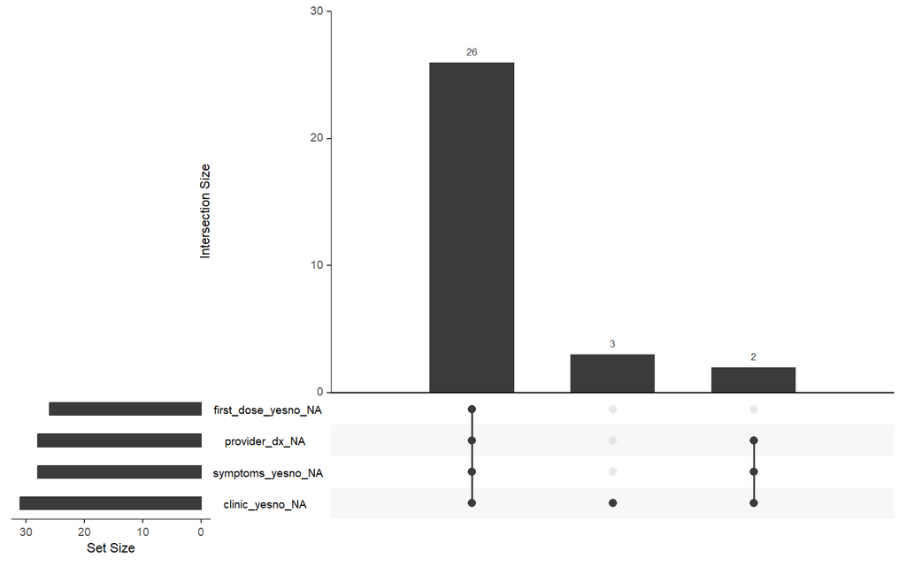

```r
mpoxve %>%
  filter(minset_vars_self == 0) %>%
  select(provider_dx, clinic_yesno, symptoms_yesno, first_dose_yesno)  %>%
  gg_miss_upset()
```

**Table 3. List of participants with an incomplete set of self-reported minimum data elements**

There is not much we can do about these missing self-reported data. I do think for the case of MN, this missingness could be do the fact that the study staff missed some of these varialbes while they were entering data during phone interviews.

```r
mpoxve %>%
  filter(minset_vars_self == 0) %>%
  select(pid, provider_dx, symptoms_yesno, clinic_yesno, first_dose_yesno) %>%
  mutate(provider_dx = fct_relevel(as_factor(case_when(provider_dx == 0 ~ "No",
                                                       provider_dx == 1 ~ "Yes",
                                                     TRUE ~ as.character(NA))),
                                   "Yes", "No"),
         symptoms_yesno = fct_relevel(as_factor(case_when(symptoms_yesno == 0 ~ "No",
                                                          symptoms_yesno == 1 ~ "Yes",
                                                     TRUE ~ as.character(NA))),
                                      "Yes", "No"),
         first_dose_yesno = fct_relevel(as_factor(case_when(first_dose_yesno == 0 ~ "No",
                                                            first_dose_yesno == 1 ~ "Yes",
                                                            TRUE ~ as.character(NA))),
                                        "Yes", "No")) %>%
  rename(PID = pid, `Provider DX` = provider_dx,
         `Clinic Visit` = clinic_yesno,
         Symptoms = symptoms_yesno, `Dose #1` = first_dose_yesno) %>%
  DT::datatable(., extensions='Buttons',
                     options = list(
                       searching = T,
                       pageLength = 15,
                       dom = 'Bfrtip',
                       buttons = c('csv')))
```

|  | PID | Provider DX | Symptoms | Clinic Visit | Dose #1 |
| --- | --- | --- | --- | --- | --- |
| 1 | MN_54 |  |  |  | Yes |
| 2 | OR_4 |  |  |  | No |
| 3 | TN_17 |  |  |  |  |
| 4 | TN_23 |  |  |  |  |
| 5 | TN_42 |  |  |  |  |
| 6 | TN_46 |  |  |  |  |
| 7 | TN_80 |  |  |  |  |
| 8 | TN_100 |  |  |  |  |
| 9 | TN_101 |  |  |  |  |
| 10 | TN_103 | Yes | Yes |  | No |

[output cut: 23 more lines]

### Distribution of case status

We restricted Table 4 to those with a complete set of self-reported minimum data elements.

The second set of results shows the distribution of enrolled participants we can include when we use the site- or self-reported case status classification and apply the symptom or clinic visit criteria. Based on this, we have 110 cases and 359 controls.

The third set of results shows that would only have 49 cases and 202 controls if we used the site case status classification along with the self-reported symptoms, which is what we are calling per protocol here. We need the sites to enter the case and vaccination status data.

**Table 4. Case status**

```r
mpoxve %>%
  filter(minset_vars_self == 1) %>%
  select(jid, caco_stat_match_f, Case_symp_f, caco) %>%
  tbl_summary(
    by = jid,
    label = list(caco_stat_match_f ~ "Case status (site versus self)",
                 Case_symp_f ~ "Case status (site or self) + symptom, clinic visit date",
                 caco ~ "Case status (per protocol)"),
     #percent = "column",
    missing = "always",
    missing_text = "Missing"

  )  %>%
  add_n() %>%
  add_overall() %>%
  bold_labels()
```

| **Characteristic** | **N** | **Overall**, N = 503<sup>1</sup> | **LAC**, N = 152 | **CT**, N = 5 | **GA**, N = 51 | **MN**, N = 164 | **NYS**, N = 9 | **OR**, N = 99 | **TN**, N = 23 |
| --- | --- | --- | --- | --- | --- | --- | --- | --- | --- |
| Case status (site versus self), n (%) | 503 |  |  |  |  |  |  |  |  |
| Case: site & self |  | 62 (12) | 0 (0) | 3 (60) | 7 (14) | 21 (13) | 9 (100) | 12 (12) | 10 (43) |
| Case: self but site missing |  | 72 (14) | 64 (42) | 0 (0) | 7 (14) | 0 (0) | 0 (0) | 1 (1.0) | 0 (0) |
| Control: site & self |  | 237 (47) | 0 (0) | 1 (20) | 10 (20) | 132 (80) | 0 (0) | 81 (82) | 13 (57) |
| Control: self but site missing |  | 122 (24) | 88 (58) | 0 (0) | 26 (51) | 8 (4.9) | 0 (0) | 0 (0) | 0 (0) |
| Discrepancy: site case |  | 1 (0.2) | 0 (0) | 1 (20) | 0 (0) | 0 (0) | 0 (0) | 0 (0) | 0 (0) |
| Discrepancy: self case |  | 9 (1.8) | 0 (0) | 0 (0) | 1 (2.0) | 3 (1.8) | 0 (0) | 5 (5.1) | 0 (0) |
| Missing |  | 0 | 0 | 0 | 0 | 0 | 0 | 0 | 0 |
| Case status (site or self) + symptom, clinic visit date, n (%) | 480 |  |  |  |  |  |  |  |  |
| Case: symptom + |  | 110 (23) | 53 (35) | 3 (75) | 11 (23) | 16 (10) | 8 (100) | 12 (13) | 7 (35) |
| Case: symptom - |  | 11 (2.3) | 11 (7.2) | 0 (0) | 0 (0) | 0 (0) | 0 (0) | 0 (0) | 0 (0) |
| Control: clinic date + |  | 359 (75) | 88 (58) | 1 (25) | 36 (77) | 140 (90) | 0 (0) | 81 (87) | 13 (65) |
| Control: clinic date - |  | 0 (0) | 0 (0) | 0 (0) | 0 (0) | 0 (0) | 0 (0) | 0 (0) | 0 (0) |
| Missing |  | 23 | 0 | 1 | 4 | 8 | 1 | 6 | 3 |
| Case status (per protocol), n (%) | 251 |  |  |  |  |  |  |  |  |
| Case |  | 49 (20) | 0 (NA) | 3 (75) | 4 (29) | 16 (14) | 8 (100) | 11 (12) | 7 (41) |
| Control |  | 202 (80) | 0 (NA) | 1 (25) | 10 (71) | 102 (86) | 0 (0) | 79 (88) | 10 (59) |
| Missing |  | 252 | 152 | 1 | 37 | 46 | 1 | 9 | 6 |

<sup>1</sup> n (%)

### List of participants missing symptoms or with a discrepancy in case status between site- and self-report

**Table 5. Participants missing symptoms or with a discrepancy in case status between site- and self-report**

```r
mpoxve %>%
   filter(#Exclude records without site-reported or self-reported case status information (the majority of these are from TN),
         (is.na(caco_stat_match_f) | minset_vars_self == 0) == F) %>%
  filter((caco_stat_match_f %in% c("Discrepancy: site case", "Discrepancy: self case") |
            Case_symp_f == "Case: symptom -") == T) %>% # restrict to those with a discrepancy in status between HD and self-report

  select(pid, Case_symp_f, caco_stat_match_f, case_yesno, provider_dx, symptoms_yesno, clinic_yesno) %>%
  mutate(case_yesno = fct_relevel(as_factor(case_when(case_yesno == 1 ~ "Case: Confirmed",
                                                      case_yesno == 2 ~ "Case: Probable",
                                                      case_yesno == 3 ~ "Control",
                                                      TRUE ~ as.character(NA))),
                                  "Case: Confirmed", "Case: Probable", "Control"),
         provider_dx = fct_relevel(as_factor(case_when(provider_dx == 0 ~ "No",
                                                       provider_dx == 1 ~ "Yes",
                                                       TRUE ~ as.character(NA))),
                                  "Yes", "No"),
         symptoms_yesno = fct_relevel(as_factor(case_when(symptoms_yesno == 0 ~ "No",
                                                          symptoms_yesno == 1 ~ "Yes",
                                                     TRUE ~ as.character(NA))),
                                      "Yes", "No")) %>%
  rename(PID = pid, `Case status (site)` = case_yesno,
         `Provider Dx (self)` = provider_dx, Symptoms = symptoms_yesno) %>%
  DT::datatable(., extensions='Buttons',
                     options = list(
                       searching = T,
                       pageLength = 15,
                       dom = 'Bfrtip',
                       buttons = c('csv')))
```

|  | PID | Case_symp_f | caco_stat_match_f | Case status (site) | Provider Dx (self) | Symptoms | clinic_yesno |
| --- | --- | --- | --- | --- | --- | --- | --- |
| 1 | CT_3 |  | Discrepancy: site case | Case: Probable | No | No | 0 |
| 2 | GA_24 |  | Discrepancy: self case | Control | No | Yes | 1 |
| 3 | LAC_059 | Case: symptom - | Case: self but site missing |  | Yes | No |  |
| 4 | LAC_1 | Case: symptom - | Case: self but site missing |  | Yes | No |  |
| 5 | LAC_16 | Case: symptom - | Case: self but site missing |  | Yes | No |  |
| 6 | LAC_17 | Case: symptom - | Case: self but site missing |  | Yes | No |  |
| 7 | LAC_18 | Case: symptom - | Case: self but site missing |  | Yes | No |  |
| 8 | LAC_34 | Case: symptom - | Case: self but site missing |  | Yes | No |  |
| 9 | LAC_42 | Case: symptom - | Case: self but site missing |  | Yes | No |  |
| 10 | LAC_83 | Case: symptom - | Case: self but site missing |  | Yes | No |  |

[output cut: 11 more lines]

## **Part 2: Plausibility of key dates (non-vaccination)**

In Part 2, we explore explore the plausibility of key dates. We restrict the analysis to participants with per protocol case status definition before apply additional restrictions where necessary.

### **List of participants with key dates outside study period: 19 Aug 2022 – 06 Jan 2023**

There are 13 enrolled participants with key dates outside the study period. Case GA_2 and MN_181 may need a closer look from the sites because their reported symptom onset dates were in June 2022. Control OR_106 also needs a closer look because they have a self-reported clinic visit date in November 2021.

For frequency matching, we plan to use the site-reported dates. Among the 10 cases, 8 (80%) had an absolute difference in days between the symptom onset and test results date <28. However, the difference in days (range: 1-27) for these eight cases is plausible given the potential lag between symptom onset and getting tested and then receiving a result, especially early in the outbreak. Among the 3 controls, 2 (67%) had an absolute difference in days between the self-reported and site-reported clinic visit date >28. *Note*: We selected >28 days as the threshold because that translates to +/- 4 weeks we will use for the time point matching criteria.

**Table 6. Participants with key dates outside study period**

```r
mpoxve %>%
   filter(#Exclude records without site-reported or self-reported case status information (the majority of these are from TN),
         (is.na(caco_stat_match_f) | minset_vars_self == 0) == F) %>%
  filter(is.na(caco) == F) %>% # restrict to per protocol definition of case status
  filter(study_pd_int_site_f == 0 | study_pd_int_self_f == 0) %>% # restrict to those without any date met
  select(caco, pid, symptoms_date, test_result_date, elig_case_date_abs,
         clinic_date, control_visit_date, elig_control_date_abs) %>%
  arrange(caco, pid) %>%
  rename(PID = pid, `Case status` = caco, `Symptom onset date` = symptoms_date,
         `Test result date` = test_result_date,
         `Abs(symtom date - test result date)` = elig_case_date_abs,
         `Clinic date (self)` = clinic_date,
         `Clinic date (site)` = control_visit_date,
         `Abs(site - self clinic date)` = elig_control_date_abs) %>%
  DT::datatable(., extensions='Buttons',
                     options = list(
                       searching = T,
                       pageLength = 15,
                       dom = 'Bfrtip',
                       buttons = c('csv')))
```

|  | Case status | PID | Symptom onset date | Test result date | Abs(symtom date - test result date) | Clinic date (self) | Clinic date (site) | Abs(site - self clinic date) |
| --- | --- | --- | --- | --- | --- | --- | --- | --- |
| 1 | Case | GA_2 | 2022-06-01 | 2022-08-21 | 81 |  |  |  |
| 2 | Case | MN_181 | 2022-06-15 | 2022-09-11 | 88 |  |  |  |
| 3 | Case | NYS_1 | 2022-08-15 | 2022-08-22 | 7 |  |  |  |
| 4 | Case | NYS_2 | 2022-08-09 | 2022-08-25 | 16 |  |  |  |
| 5 | Case | OR_66 | 2022-07-27 | 2022-07-26 | 1 |  |  |  |
| 6 | Case | OR_8 | 2022-08-10 | 2022-08-31 | 21 |  |  |  |
| 7 | Case | OR_99 | 2022-08-08 | 2022-08-17 | 9 |  |  |  |
| 8 | Case | TN_208 | 2022-08-01 | 2022-08-28 | 27 |  |  |  |
| 9 | Case | TN_213 | 2022-08-15 | 2022-09-01 | 17 |  |  |  |
| 10 | Case | TN_32 | 2022-08-15 | 2022-08-27 | 12 |  |  |  |

[output cut: 3 more lines]

### **Symptom Onset Date vs Test Date (Cases)**

How should we handle these 11 records where the symptom onset date is after the positive test result?

**Table 7. list of cases with symptom onset date after positive test result**

```r
mpoxve %>%
   filter(#Exclude records without site-reported or self-reported case status information (the majority of these are from TN),
         (is.na(caco_stat_match_f) | minset_vars_self == 0) == F) %>%
  filter(caco == "Case" & symp_gt_test_date_f == "Yes") %>% # restrict to per protocol definition of case status = cases
  select(pid, symptoms_date, test_result_date, elig_case_date_abs) %>%
  arrange(elig_case_date_abs) %>%
  rename(PID = pid, `Symptom onset date` = symptoms_date,
         `Test result date` = test_result_date,
         `Abs(symtom date - test result date)` = elig_case_date_abs) %>%
  DT::datatable(., extensions='Buttons',
                     options = list(
                       searching = T,
                       pageLength = 15,
                       dom = 'Bfrtip',
                       buttons = c('csv')))
```

|  | PID | Symptom onset date | Test result date | Abs(symtom date - test result date) |
| --- | --- | --- | --- | --- |
| 1 | MN_4 | 2022-09-01 | 2022-08-31 | 1 |
| 2 | OR_66 | 2022-07-27 | 2022-07-26 | 1 |
| 3 | CT_4 | 2022-10-17 | 2022-10-14 | 3 |
| 4 | MN_138 | 2022-09-01 | 2022-08-29 | 3 |
| 5 | NYS_24 | 2022-10-16 | 2022-10-12 | 4 |
| 6 | MN_165 | 2022-09-08 | 2022-08-29 | 10 |
| 7 | MN_10 | 2022-09-18 | 2022-09-04 | 14 |
| 8 | GA_14 | 2022-09-08 | 2022-08-19 | 20 |
| 9 | NYS_16 | 2022-10-12 | 2022-09-21 | 21 |
| 10 | GA_3 | 2022-09-20 | 2022-08-20 | 31 |

[output cut: 1 more lines]

### **Clinic visit date—site vs Self report (controls)**

**Table 8. list of controls with absolute difference in days between the site and self-reported clinic date is >2**

```r
mpoxve %>%
   filter(#Exclude records without site-reported or self-reported case status information (the majority of these are from TN),
         (is.na(caco_stat_match_f) | minset_vars_self == 0) == F) %>%
  filter(caco == "Control" & clinic_v_control_date == "Abs > 2: Yes") %>% # restrict to per protocol definition of case status = cases
  select(pid, control_visit_date, clinic_date, elig_control_date_abs) %>%
  arrange(elig_control_date_abs) %>%
  rename(PID = pid, `Clinic date` = control_visit_date,
         `Clinic date (self)` = clinic_date,
         `Abs(site - self clinic date)` = elig_control_date_abs) %>%
  DT::datatable(., extensions='Buttons',
                     options = list(
                       searching = T,
                       pageLength = 15,
                       dom = 'Bfrtip',
                       buttons = c('csv')))
```

|  | PID | Clinic date | Clinic date (self) | Abs(site - self clinic date) |
| --- | --- | --- | --- | --- |
| 1 | OR_67 | 2022-09-16 | 2022-09-19 | 3 |
| 2 | GA_12 | 2022-10-08 | 2022-10-12 | 4 |
| 3 | OR_17 | 2022-09-06 | 2022-09-10 | 4 |
| 4 | OR_25 | 2022-10-28 | 2022-11-01 | 4 |
| 5 | OR_42 | 2022-09-27 | 2022-09-23 | 4 |
| 6 | TN_10040 | 2022-10-14 | 2022-10-18 | 4 |
| 7 | OR_85 | 2022-10-10 | 2022-10-05 | 5 |
| 8 | OR_74 | 2022-09-27 | 2022-09-20 | 7 |
| 9 | OR_96 | 2022-09-07 | 2022-08-31 | 7 |
| 10 | OR_16 | 2022-09-21 | 2022-09-13 | 8 |

[output cut: 47 more lines]

### **Smallpox vaccination year**

**Table 9. Smallpox vaccination timing**

```r
mpoxve %>%
   filter(#Exclude records without site-reported or self-reported case status information (the majority of these are from TN),
         (is.na(caco_stat_match_f) | minset_vars_self == 0) == F) %>%
  filter(is.na(caco) == F) %>%
  select(caco, smallpox_birth_f) %>%
  tbl_summary(
    by = caco,
    label = list(smallpox_birth_f ~ "Smallpox"),
    missing = "always",
    missing_text = "Missing"

  )  %>%
  add_n() %>%
  add_overall() %>%
  bold_labels()
```

| **Characteristic** | **N** | **Overall**, N = 251<sup>1</sup> | **Case**, N = 49 | **Control**, N = 202 |
| --- | --- | --- | --- | --- |
| Smallpox, n (%) | 248 |  |  |  |
| Plausible |  | 245 (99) | 48 (100) | 197 (98) |
| Vax year missing |  | 3 (1.2) | 0 (0) | 3 (1.5) |
| Missing |  | 3 | 1 | 2 |

<sup>1</sup> n (%)

## **Part 3: Vaccination related variables**

### **Table 10. Dose 1 and Dose 2 vaccination interval: site & self**

```r
mpoxve %>%
   filter(#Exclude records without site-reported or self-reported case status information (the majority of these are from TN),
         (is.na(caco_stat_match_f) | minset_vars_self == 0) == F) %>%
  filter(is.na(caco) == F) %>%
  select(caco, dose_int_cat_site, dose_int_cat_self) %>%
  tbl_summary(
    by = caco,
    label = list(dose_int_cat_site ~ "Site",
                 dose_int_cat_self ~ "Self"),
    missing = "always",
    missing_text = "Missing"

  )  %>%
  add_n() %>%
  add_overall() %>%
  bold_labels()
```

| **Characteristic** | **N** | **Overall**, N = 251<sup>1</sup> | **Case**, N = 49 | **Control**, N = 202 |
| --- | --- | --- | --- | --- |
| Site, n (%) | 247 |  |  |  |
| Dose #1 only |  | 40 (16) | 10 (20) | 30 (15) |
| <24 days |  | 0 (0) | 0 (0) | 0 (0) |
| 24-28 days |  | 36 (15) | 2 (4.1) | 34 (17) |
| >28 days |  | 123 (50) | 5 (10) | 118 (60) |
| Not Vaxed |  | 48 (19) | 32 (65) | 16 (8.1) |
| Missing |  | 4 | 0 | 4 |
| Self, n (%) | 251 |  |  |  |
| Dose #1 only |  | 29 (12) | 9 (18) | 20 (9.9) |
| <24 days |  | 13 (5.2) | 1 (2.0) | 12 (5.9) |
| 24-28 days |  | 31 (12) | 1 (2.0) | 30 (15) |
| >28 days |  | 131 (52) | 6 (12) | 125 (62) |
| Not Vaxed |  | 47 (19) | 32 (65) | 15 (7.4) |
| Missing |  | 0 | 0 | 0 |

<sup>1</sup> n (%)

### **Table 11. Vaccine dose number: site versus self**

```r
mpoxve %>%
   filter(#Exclude records without site-reported or self-reported case status information (the majority of these are from TN),
         (is.na(caco_stat_match_f) | minset_vars_self == 0) == F) %>%
  filter(is.na(caco) == F) %>%
  select(caco, site_v_self_dose1, site_v_self_dose2) %>%
  tbl_summary(
    by = caco,
    label = list(site_v_self_dose1 ~ "Dose #1",
                 site_v_self_dose2 ~ "Dose #2"),
    missing = "always",
    missing_text = "Missing"

  )  %>%
  add_n() %>%
  add_overall() %>%
  bold_labels()
```

| **Characteristic** | **N** | **Overall**, N = 251<sup>1</sup> | **Case**, N = 49 | **Control**, N = 202 |
| --- | --- | --- | --- | --- |
| Dose #1, n (%) | 248 |  |  |  |
| Same |  | 244 (98) | 47 (96) | 197 (99) |
| Site-Vax |  | 1 (0.4) | 1 (2.0) | 0 (0) |
| Self-Vaxed |  | 3 (1.2) | 1 (2.0) | 2 (1.0) |
| Missing |  | 3 | 0 | 3 |
| Dose #2, n (%) | 200 |  |  |  |
| Same |  | 185 (92) | 15 (94) | 170 (92) |
| Site-Vax |  | 0 (0) | 0 (0) | 0 (0) |
| Self-Vaxed |  | 15 (7.5) | 1 (6.2) | 14 (7.6) |
| Missing |  | 51 | 33 | 18 |

<sup>1</sup> n (%)

### **Table 12. Vaccine administration date: site versus self (+/- 2 days)**

```r
mpoxve %>%
   filter(#Exclude records without site-reported or self-reported case status information (the majority of these are from TN),
         (is.na(caco_stat_match_f) | minset_vars_self == 0) == F) %>%
  filter(is.na(caco) == F) %>%
  select(caco, site_v_self_vaxdate1, site_v_self_vaxdate2) %>%
  tbl_summary(
    by = caco,
    label = list(site_v_self_vaxdate1 ~ "Dose #1",
                 site_v_self_vaxdate2 ~ "Dose #2"),
    missing = "always",
    missing_text = "Missing"

  )  %>%
  add_n() %>%
  add_overall() %>%
  bold_labels()
```

| **Characteristic** | **N** | **Overall**, N = 251<sup>1</sup> | **Case**, N = 49 | **Control**, N = 202 |
| --- | --- | --- | --- | --- |
| Dose #1, n (%) | 198 |  |  |  |
| Abs > 2: Yes |  | 93 (47) | 9 (56) | 84 (46) |
| Abs > 2: No |  | 105 (53) | 7 (44) | 98 (54) |
| Missing |  | 53 | 33 | 20 |
| Dose #2, n (%) | 160 |  |  |  |
| Abs > 2: Yes |  | 64 (40) | 5 (71) | 59 (39) |
| Abs > 2: No |  | 96 (60) | 2 (29) | 94 (61) |
| Missing |  | 91 | 42 | 49 |

<sup>1</sup> n (%)

## **Part 4: Vaccination Status**

Do we account for the index date (mpox symptom onset [for cases] or clinic visit date [for controls]) to calculate vaccination coverage in our study? If we do, then coverage is low (Table 13). The proportion of those vaccinated after the index date was high, especially among controls (Table 14).

**Definitions:**

- Fully vaccinated: Receipt of two doses of JYNNEOS vaccine at least 24 days apart, with the second dose having been administered >13 days before index date (mpox symptom onset [for cases] or clinic visit date [for controls]).
- Partially vaccinated: Receipt of one dose of JYNNEOS vaccine >13 days before index date or participants with receipt of two doses of JYNNEOS vaccine <14 days before index date.
- Unvaccinated: Without receipt of any doses of JYNNEOS vaccine or receipt of the vaccine after index date
  - Vaccinated post-index date: We wanted to pull these people out (see Table 14) to ask what would be the impact of this high proportion on the VE results? Does it impact statistical power if we account for index date in the vaccination coverage calculation?
- PEP vaccination: Receipt of one dose of JYNNEOS vaccine within 13 days after exposure to a person diagnosed with mpox (confirmed or probable case) and before index date.
  - In the analysis plan, this definition is presented in the tables as a mutually exclusive category, but it is not. Because of this and we have not delved into the mpox exposure history variables, we have not coded it yet

**Table 13. Distribution of vaccination status—three levels**

```r
mpoxve %>%
   filter(#Exclude records without site-reported or self-reported case status information (the majority of these are from TN),
         (is.na(caco_stat_match_f) | minset_vars_self == 0) == F) %>%
  filter(is.na(caco) == F) %>%
  select(caco, vax_stat_site, vax_stat_self) %>%
  tbl_summary(
    by = caco,
    label = list(vax_stat_site ~ "Site",
                 vax_stat_self ~ "Self"

                 ),
     #percent = "column",
    missing = "always",
    missing_text = "Missing"

  )  %>%
  add_n() %>%
  add_overall() %>%
  bold_labels()
```

| **Characteristic** | **N** | **Overall**, N = 251<sup>1</sup> | **Case**, N = 49 | **Control**, N = 202 |
| --- | --- | --- | --- | --- |
| Site, n (%) | 236 |  |  |  |
| Full |  | 20 (8.5) | 2 (4.2) | 18 (9.6) |
| Partial |  | 4 (1.7) | 2 (4.2) | 2 (1.1) |
| Unvaccinated |  | 212 (90) | 44 (92) | 168 (89) |
| Missing |  | 15 | 1 | 14 |
| Self, n (%) | 242 |  |  |  |
| Full |  | 24 (9.9) | 2 (4.3) | 22 (11) |
| Partial |  | 6 (2.5) | 1 (2.1) | 5 (2.6) |
| Unvaccinated |  | 212 (88) | 44 (94) | 168 (86) |
| Missing |  | 9 | 2 | 7 |

<sup>1</sup> n (%)

**Table 14. Distribution of status—four levels**

```r
mpoxve %>%
   filter(#Exclude records without site-reported or self-reported case status information (the majority of these are from TN),
         (is.na(caco_stat_match_f) | minset_vars_self == 0) == F) %>%
  filter(is.na(caco) == F) %>%
  select(caco, vax_stat_4cat_site, vax_stat_4cat_self) %>%
  tbl_summary(
    by = caco,
    label = list(vax_stat_4cat_site ~ "Site",
                 vax_stat_4cat_self ~ "Self"

                 ),
     #percent = "column",
    missing = "always",
    missing_text = "Missing"

  )  %>%
  add_n() %>%
  add_overall() %>%
  bold_labels()
```

| **Characteristic** | **N** | **Overall**, N = 251<sup>1</sup> | **Case**, N = 49 | **Control**, N = 202 |
| --- | --- | --- | --- | --- |
| Site, n (%) | 236 |  |  |  |
| Full |  | 20 (8.5) | 2 (4.2) | 18 (9.6) |
| Partial |  | 4 (1.7) | 2 (4.2) | 2 (1.1) |
| Vax post-index |  | 164 (69) | 12 (25) | 152 (81) |
| Unvaccinated |  | 48 (20) | 32 (67) | 16 (8.5) |
| Missing |  | 15 | 1 | 14 |
| Self, n (%) | 242 |  |  |  |
| Full |  | 24 (9.9) | 2 (4.3) | 22 (11) |
| Partial |  | 6 (2.5) | 1 (2.1) | 5 (2.6) |
| Vax post-index |  | 165 (68) | 12 (26) | 153 (78) |
| Unvaccinated |  | 47 (19) | 32 (68) | 15 (7.7) |
| Missing |  | 9 | 2 | 7 |

<sup>1</sup> n (%)

## **Part 5: Age, hospitalization, and number of sexual partners**

### **Age**

**Table 15. Distribution of age**

```r
mpoxve %>%
   filter(#Exclude records without site-reported or self-reported case status information (the majority of these are from TN),
         (is.na(caco_stat_match_f) | minset_vars_self == 0) == F) %>%
  filter(is.na(caco) == F) %>%
  select(caco, age_f, age_cat) %>%
  tbl_summary(
    by = caco,
    label = list(age_f ~ "Age",
                 age_cat ~ "Age Distribution"),
    missing = "always",
    missing_text = "Missing"

  )  %>%
  add_n() %>%
  add_overall() %>%
  bold_labels()
```

| **Characteristic** | **N** | **Overall**, N = 251<sup>1</sup> | **Case**, N = 49 | **Control**, N = 202 |
| --- | --- | --- | --- | --- |
| Age, n (%) | 251 |  |  |  |
| 18-49 |  | 248 (99) | 46 (94) | 202 (100) |
| ≥50 |  | 3 (1.2) | 3 (6.1) | 0 (0) |
| Missing |  | 0 | 0 | 0 |
| Age Distribution, n (%) | 251 |  |  |  |
| 18-29 |  | 58 (23) | 9 (18) | 49 (24) |
| 30-39 |  | 129 (51) | 27 (55) | 102 (50) |
| 40-49 |  | 61 (24) | 10 (20) | 51 (25) |
| 50 |  | 3 (1.2) | 3 (6.1) | 0 (0) |
| Missing |  | 0 | 0 | 0 |

<sup>1</sup> n (%)

### **Length of hospitalization**

For the length of Hospitalization, we want to examine if length of days of hospitalization is longer than the time between illness onset and survey submission (flag if hospitalized_days > (submitted date - symptoms_date). However, we do not have a ‘submitted date’ variable at CDC as the sites are not uploading the time stamps. However, only 4 people reported being hospitalized and their days of hospitalization seem plausible. *Note*: Length of hospitalization was assessed among those who self-reported as having been told by a provider they have mpox.

**Table 16. Distribution of hospitalization**

```r
mpoxve %>%
   filter(#Exclude records without site-reported or self-reported case status information (the majority of these are from TN),
         (is.na(caco_stat_match_f) | minset_vars_self == 0) == F) %>%
  filter(caco == "Case") %>%
  select(hospitalized_cat, hospitalized_days_cat) %>%
  tbl_summary(
    label = list(hospitalized_cat ~ "Hospital",
                 hospitalized_days_cat ~ "Days hospitalized" ),
    missing = "always",
    missing_text = "Missing"
  )  %>%
  add_n() %>%
  bold_labels()
```

| **Characteristic** | **N** | **N = 49** |
| --- | --- | --- |
| Hospital, n (%) | 49 | 4 (8.2) |
| Missing |  | 0 |
| Days hospitalized, n (%) | 4 |  |
| 0 |  | 1 (25) |
| 1-7 |  | 2 (50) |
| 8-14 |  | 1 (25) |
| 15-21 |  | 0 (0) |
| ≥29 |  | 0 (0) |
| Missing |  | 45 |

### **Number of sexual partners**

For the number of sexual partners, we want to examine the distribution of number of sexual partners for any implausible values. What values should we consider as implausible?

**Table 17. Distribution of sexual partners**

```r
mpoxve %>%
   filter(#Exclude records without site-reported or self-reported case status information (the majority of these are from TN),
         (is.na(caco_stat_match_f) | minset_vars_self == 0) == F) %>%
  filter(is.na(caco) == F) %>%
  select(caco, sex_part_num, sex_part_num_cat) %>%
  tbl_summary(
    by = caco,
    label = list(sex_part_num ~ "# sexual partners",
                 sex_part_num_cat ~ "# sexual partners"
                 ),
    missing = "always",
    missing_text = "Missing"

  )  %>%
  add_n() %>%
  add_overall() %>%
  bold_labels()
```

| **Characteristic** | **N** | **Overall**, N = 251<sup>1</sup> | **Case**, N = 49 | **Control**, N = 202 |
| --- | --- | --- | --- | --- |
| # sexual partners, Median (IQR) | 238 | 3 (2 – 5) | 3 (1 – 4) | 3 (2 – 5) |
| Missing |  | 13 | 1 | 12 |
| # sexual partners, n (%) | 238 |  |  |  |
| 0 |  | 7 (2.9) | 2 (4.2) | 5 (2.6) |
| 1-3 |  | 139 (58) | 32 (67) | 107 (56) |
| 4-6 |  | 59 (25) | 9 (19) | 50 (26) |
| 7-9 |  | 11 (4.6) | 1 (2.1) | 10 (5.3) |
| 10-12 |  | 10 (4.2) | 2 (4.2) | 8 (4.2) |
| 13+ |  | 12 (5.0) | 2 (4.2) | 10 (5.3) |
| Missing |  | 13 | 1 | 12 |

<sup>1</sup> Median (IQR); n (%)